# Neural Network First List

Building a neural network from scratch

Author

Micael Egídio Papa da Silva

Published

15-05-2024

# Generating the Data

Consider a data-generating process in the form:

$$\begin{align*}
Y & \sim N(\mu, \sigma=1) \\
\mu & = |X_1^3 - 30 \sin(X_2) + 10| \\
X_j & \sim \text{Uniform}(-3, 3), \quad j=1, 2.
\end{align*}$$

In this list, we are interested in estimating the above model using a simple neural network, adjusted on simulated data. Specifically, we want to build a neural network with only one hidden layer containing two neurons.

Mathematically, the network is described by the following equations:

$$\begin{align*}
h_1 & = \phi(x_1 w_1 + x_2 w_3 + b_1) = \phi(a_1) \\
h_2 & = \phi(x_1 w_2 + x_2 w_4 + b_2) = \phi(a_2) \\
\hat{y} & = h_1 w_5 + h_2 w_6 + b_3,
\end{align*}$$

where $\phi(x) = \frac{1}{1+e^{-x}}$ represents the logistic activation function (sigmoid).

We will adopt the mean squared error as the cost function, expressed as:

$$J(\theta) = \frac{1}{m} \sum_{i=1}^m L(f(x_{1i}, x_{2i}; \theta), y_i) = \frac{1}{m} \sum_{i=1}^m (y_i - \hat{y}_i)^2,$$

$$f(x_{1i}, x_{2i}; \theta)=\hat{y}_i=\phi(x_{1i} w_1 + x_{2i} w_3 + b_1) w_5 + \phi(x_{1i} w_2 + x_{2i} w_4 + b_2) w_6 + b_3.$$

In matrix notation, the neural network can be described as:

$$\begin{align*}
\mathbf{a} & = \mathbf{W}^{(1)\top} \mathbf{x} + \mathbf{b}^{(1)} \\
\mathbf{h} & = \phi(\mathbf{a}) \\
\hat{y} & = \mathbf{W}^{(2)\top} \mathbf{h} + b_3
\end{align*}$$

where

$$\mathbf{W}^{(1)}=\begin{pmatrix}
w_1 & w_2 \\
w_3 & w_4
\end{pmatrix}, \quad \mathbf{W}^{(2)} = \begin{pmatrix}
w_5 \\
w_6
\end{pmatrix}, \quad \mathbf{b}^{(1)} = \begin{pmatrix}
b_1 \\
b_2
\end{pmatrix}, \quad
\mathbf{x} = \begin{pmatrix}
x_1 \\
x_2
\end{pmatrix}, \quad
\mathbf{h} = \begin{pmatrix}
h_1 \\
h_2
\end{pmatrix}, \quad
\mathbf{a} = \begin{pmatrix}
a_1 \\
a_2
\end{pmatrix}.$$

# Libraries

**Show/hide code**

```python
import numpy as np
import pandas as pd

import scipy.stats as st
import statsmodels.formula.api as smf

import seaborn as sns
import matplotlib.pyplot as plt
import plotly.graph_objects as go
import plotly.express as px
import plotly.io as pio
```

# Functions

**Show/hide code**

```python
class SimpleNeuralNetwork:
    """
    Class implementing a simple neural network.

    Attributes:
        W_1 (ndarray): Weights of the first layer of the network.
        W_2 (ndarray): Weights of the second layer of the network.
        b_1 (ndarray): Bias of the first layer of the network.
        b_2 (ndarray): Bias of the second layer of the network.

    Methods:
        sigmoid(self, x): Sigmoid activation function.
        loss(self, y_hat, y): Computes the loss function of the network.
        derivative_loss(self, y_hat, y): Computes the derivative of the loss function.
        forward_pass(self, X, theta): Performs forward pass through the neural network.
        backpropagation(self, y_hat, y, X): Performs backpropagation of gradients through the neural network.
        loss_calculation(self, y_hat, y): Computes the loss function of the network.
        forward_pass_L2(self, X, theta, lambda_val): Performs forward pass through the neural network with L2 regularization.
        backpropagation_L2(self, y_hat, y, X, lambda_val): Performs backpropagation of gradients through the neural network with L2 regularization.
        loss_calculation_L2(self, y_hat, y, lambda_val): Computes the loss function of the network with L2 regularization.
        operate(self, X, theta, y=None, operation='forward', lambda_val=None): Performs operations on the network, such as forward pass, backpropagation, loss calculation, etc.
    """
    def __init__(self):
        self.W_1 = None
        self.W_2 = None
        self.b_1 = None
        self.b_2 = None

    def sigmoid(self, x):
        return 1 / (1 + np.exp(-x))

    def loss(self, y_hat, y):
        return np.mean((y_hat - y) ** 2)

    def derivative_loss(self, y_hat, y):
        return 2 * (y_hat - y) / y.shape[0]

    def forward_pass(self, X, theta):
        self.W_1 = theta[:4].reshape(2, 2)
        self.W_2 = theta[4:6].reshape(2, 1)
        self.b_1 = np.tile(theta[6:8].reshape(1, 2), (X.shape[0], 1))
        self.b_2 = theta[8].reshape(1, 1)

        A_1 = X @ self.W_1 + self.b_1
        H_1 = self.sigmoid(A_1)
        y_hat = H_1 @ self.W_2 + self.b_2

        return y_hat

    def backpropagation(self, y_hat, y, X):
        H_1 = self.sigmoid(X @ self.W_1 + self.b_1)
        dA_2 = self.derivative_loss(y_hat, y)
        dW_2 = H_1.T @ dA_2
        db_2 = np.sum(dA_2, axis=0, keepdims=True)

        dH_1 = dA_2 @ self.W_2.T
        dA_1 = dH_1 * H_1 * (1 - H_1)  ##  H_1 * (1 - H_1) is the derivative of the sigmoid calculated at H_1
        dW_1 = X.T @ dA_1
        db_1 = np.sum(dA_1, axis=0, keepdims=True)

        gradients = np.hstack((dW_1.ravel(), dW_2.ravel(), db_1.ravel(), db_2.ravel()))
        return gradients

    def loss_calculation(self, y_hat, y):
        return self.loss(y_hat, y)

    def forward_pass_L2(self, X, theta, lambda_val):
        self.W_1 = theta[:4].reshape(2, 2)
        self.W_2 = theta[4:6].reshape(2, 1)
        self.b_1 = np.tile(theta[6:8].reshape(1, 2), (X.shape[0], 1))
        self.b_2 = theta[8].reshape(1, 1)

        A_1 = X @ self.W_1 + self.b_1
        H_1 = self.sigmoid(A_1)
        y_hat = H_1 @ self.W_2 + self.b_2 + lambda_val * (np.sum(self.W_1 ** 2) + np.sum(self.W_2 ** 2))

        return y_hat

    def backpropagation_L2(self, y_hat, y, X, lambda_val):
        H_1 = self.sigmoid(X @ self.W_1 + self.b_1)
        dA_2 = self.derivative_loss(y_hat, y) + 2 * lambda_val * self.W_2.T
        dW_2 = H_1.T @ dA_2
        db_2 = np.sum(dA_2, axis=0, keepdims=True)

        dH_1 = dA_2 @ self.W_2
        dA_1 = dH_1 * H_1 * (1 - H_1)
        dW_1 = X.T @ dA_1 + 2 * lambda_val * self.W_1
        db_1 = np.sum(dA_1, axis=0, keepdims=True)

        gradients = np.hstack((dW_1.ravel(), dW_2.ravel(), db_1.ravel(), db_2.ravel()))
        return gradients

    def loss_calculation_L2(self, y_hat, y, lambda_val):
        return self.loss(y_hat, y) + lambda_val * (np.sum(self.W_1 ** 2) + np.sum(self.W_2 ** 2))

    def operate(self, X, theta, y=None, operation='forward', lambda_val=None):
        if operation == 'forward':
            return self.forward_pass(X, theta)
        elif operation == 'backpropagation':
            y_hat = self.forward_pass(X, theta)
            return self.backpropagation(y_hat, y, X)
        elif operation == 'loss':
            y_hat = self.forward_pass(X, theta)
            return self.loss_calculation(y_hat, y)
        elif operation == 'forward_L2':
            return self.forward_pass_L2(X, theta, lambda_val)
        elif operation == 'backpropagation_L2':
            y_hat = self.forward_pass_L2(X, theta, lambda_val)
            return self.backpropagation_L2(y_hat, y, X, lambda_val)
        elif operation == 'loss_L2':
            y_hat = self.forward_pass_L2(X, theta, lambda_val)
            return self.loss_calculation_L2(y_hat, y, lambda_val)



#### Data vis

def create_parameter_table(theta):
    """
    Create a parameter table DataFrame from a given theta array.

    Parameters:
    - theta (numpy.ndarray): The parameter array containing weights and biases.

    Returns:
    - pd.DataFrame: DataFrame representing the parameter table (transposed).
    """
    theta_list = theta.tolist()
    num_params = len(theta_list) - 3
    num_biases = 3

    param_column_names = [f'w_{i+1}' for i in range(num_params)]
    bias_column_names = [f'b_{i+1}' for i in range(num_biases)]
    column_names = param_column_names + bias_column_names

    parameter_table = pd.DataFrame([theta_list], columns=column_names).T

    parameter_table.columns = ['']

    return parameter_table


def create_gradient_plot():
    """
    Create a plot showing the gradient as a function of the number of iterations.

    This function generates a plot with two traces: one representing the gradient as a function of
    the number of iterations, and the other representing the previous gradient. It visualizes how
    the gradient changes over the course of the iterations.

    Returns:
    - fig (plotly.graph_objects.Figure): Plotly figure object representing the gradient plot.
    """

    theta = np.array([0.1] * 9)
    data_array = np.array(data)

    dJ_dw_1 = [nn.operate(data_array[:k, :2], theta, data_array[:k, 2].reshape(k, 1), "backpropagation")[0] for k in range(300)]

    x_values = list(range(len(dJ_dw_1)))
    y_red_line = nn.operate(x_train, theta, y_train, "backpropagation")[0]

    trace1 = go.Scatter(x=x_values, y=dJ_dw_1, mode='lines', name='Gradient', line=dict(color='white', width=2))
    trace2 = go.Scatter(x=x_values, y=[y_red_line] * len(x_values), mode='lines', name='Previous gradient', line=dict(color='red', width=2, dash='dashdot'))

    fig = go.Figure(data=[trace1, trace2])

    fig.update_layout(title='∂J/∂w₁ as a function of Number of Iterations',
                      xaxis_title='Number of iterations',
                      yaxis_title='',
                      hovermode='closest',
                      legend=dict(font=dict(color='white')),
                      template='plotly_dark')


    return fig

def generate_traces(all_parameters_df):
    W1_weights = all_parameters_df.loc[['w_1', 'w_3']]   ## w_1 = w_2 and w_3 = w_4
    W2_weights = all_parameters_df.loc[['w_5']]          ## w_5 = w_6
    B1_biases = all_parameters_df.loc[['b_1']]    ## b_1 = b_2
    B2_biases = all_parameters_df.loc[['b_3']]

    traces = []

    for i, row in enumerate(B2_biases.values):
        label = f'b{i+3}'
        trace = go.Scatter(x=np.arange(len(row)), y=row, mode='lines', name=label)
        traces.append(trace)

    for i, row in enumerate(B1_biases.values):
        label = 'b1 = b2' if i == 0 else None
        trace = go.Scatter(x=np.arange(len(row)), y=row, mode='lines', name=label)
        traces.append(trace)

    for i, row in enumerate(W1_weights.values):
        label = 'w1 = w2' if i == 0 else 'w3 = w4'
        trace = go.Scatter(x=np.arange(len(row)), y=row, mode='lines', name=label)
        traces.append(trace)

    for i, row in enumerate(W2_weights.values):
        label = 'w5 = w6' if i == 0 else None
        trace = go.Scatter(x=np.arange(len(row)), y=row, mode='lines', name=label)
        traces.append(trace)

    return traces

def plot_weights_biases_behavior(all_parameters_df, best_epoch=17):
    traces = generate_traces(all_parameters_df)

    best_params_values = [all_parameters_df.values[i][best_epoch] for i in range(5)]

    scatter_trace = go.Scatter(x=[best_epoch] * 5,
                               y=best_params_values,
                               mode='markers',
                               marker=dict(color='purple', size=10),
                               name='Best Params')

    traces.append(scatter_trace)

    layout = go.Layout(
        title='Behavior of Weights and Biases over Epochs',
        xaxis=dict(title='Epoch'),
        yaxis=dict(title='Value'),
        legend=dict(orientation='h', x=0, y=-0.2),
        hovermode='closest',
    )

    y_min = min(all_parameters_df.values.min(axis=1))
    y_max = max(all_parameters_df.values.max(axis=1))

    shapes = [
        dict(
            type="rect",
            x0=best_epoch,
            y0=y_min,
            x1=best_epoch,
            y1=y_max,
            line=dict(color="purple", width=2),
            name=f'Epoch {best_epoch}'
        )
    ]

    fig = go.Figure(data=traces, layout=layout)
    fig.update_layout(shapes=shapes, legend_traceorder='reversed', showlegend=True, legend_title='')
    fig.show()

def calculate_timing(k):
    """

    This function measures the average execution time of the backpropagation
    for the first `k` rows of the data.

    Parameters:
    - k (int): Number of rows to consider from the data.

    Returns:
    - average_timing (float): Average execution time of the neural network operation in seconds.
    """
    x = data.__array__()[:k, :2]
    y = data.__array__()[:k, 2].reshape(k, 1)
    timing = %timeit -o nn.operate(x, theta, y, "backpropagation")
    return timing.average



def calculate_capture_rate(predictions, z):
    """
    Calculate the capture rate.

    Capture rate is the percentage of predictions falling within a specified range [-z, z].

    Parameters:
    - predictions (array-like): Predicted values.
    - z (float): Threshold value defining the range.

    Returns:
    - capture_rate (float): Percentage of predictions falling within the range [-z, z].
    """
    capture_rate = ((predictions >= -z) & (predictions <= z)).mean() * 100
    return capture_rate
```

# Questions

**Considering the information above, answer the following items.**

## **a)**

Create a computational function to calculate the predicted value of the response variable $\hat{y}=f(\mathbf{x}; \pmb{\theta})$ as a function of $\mathbf{x}$ and $\pmb{\theta}$. Use the function to calculate $\hat{y}$ for $\pmb{\theta}=(0.1, \ldots, 0.1)$ and $\mathbf{x}=(1, 1)$. Hint: see Algorithm 6.3 of the book Deep Learning.

The algorithm was adapted to a matrix calculation, which is more efficient.

**Show/hide code**

```python
nn = SimpleNeuralNetwork()

theta = np.array([0.1] * 9)
X = np.array([1] * 2).reshape(1, 2)

y_hat = nn.operate(X, theta)


print(f'Predicted value obtained was {y_hat.item():.3f}')
```

```
Predicted value obtained was 0.215
```

## **b)**

Create a computational routine to calculate the cost function $J(\bf{\theta})$. Then, divide the observed dataset so that the **first** 80,000 samples comprise the **training** set, the next 10,000 comprise the **validation** set, and the **last** 10,000 comprise the **test** set. What is the cost of the network **on the test set** when $\bf{\theta}=(0.1, \ldots, 0.1)$?

**Show/hide code**

```python
data = pd.read_csv('/home/micaelpapa/Desktop/Neural-Nets/Neural-Nets.csv', dtype=np.float64, index_col=0).reset_index(drop=True)

# Dividing the data into training, validation, and test sets.

x_train = data.__array__()[:80000, :2]
y_train = data.__array__()[:80000, 3].reshape(80000, 1)

x_val = data.__array__()[80000:90000, :2]
y_val = data.__array__()[80000:90000, 3].reshape(10000, 1)

x_test = data.__array__()[-10000:, :2]
y_test = data.__array__()[-10000:, 3].reshape(10000, 1)



train_data = data.iloc[:80000, [0, 1, -1]].rename(columns={'x1.obs': 'x1', 'x2.obs': 'x2'})

test_data = data.iloc[90000:, [0, 1, -1]].rename(columns={'x1.obs': 'x1', 'x2.obs': 'x2'})

val_data = data.iloc[-10000:, [0, 1, -1]].rename(columns={'x1.obs': 'x1', 'x2.obs': 'x2'})

theta = np.array([0.1] * 9)

print(f'Cost of the network on the test set: {nn.operate(x_test, theta, y_test, "loss"):.3f}')
```

```
Cost of the network on the test set: 663.129
```

## **c)**

Use the chain rule to find algebraic expressions for the gradient vector

$$\nabla_\theta J(\pmb{\theta}) = \left(\frac{\partial J}{\partial w_1},
\ldots, \frac{\partial J}{\partial b_3} \right).$$

we can see that :

$$\begin{align*}
\frac{\partial J}{\partial \hat{y}} = \sum_{i=1}^n \frac{-2}{m} (y_i - \hat{y}_i) = \sum_{i=1}^n \frac{2}{m} (\hat{y}_i - y_i) \\
\end{align*}$$

Next we have:

$$\begin{align*}
\frac{\partial J}{\partial w_1} & = \frac{\partial J}{\partial \hat{y}} \frac{\partial \hat{y}}{\partial h^1} \frac{\partial h^1}{\partial a^1} \frac{\partial a^1}{\partial w_1} = \sum_{i=1}^n \frac{2}{m} (\hat{y}_i - y_i) \cdot w_5 \cdot \phi'(a_{i,1}) \cdot x_i^1 \\
\frac{\partial J}{\partial w_2} & = \frac{\partial J}{\partial \hat{y}} \frac{\partial \hat{y}}{\partial h^2} \frac{\partial h^2}{\partial a^2} \frac{\partial a^2}{\partial w_2} = \sum_{i=1}^n \frac{2}{m} (\hat{y}_i - y_i) \cdot w_6 \cdot \phi'(a_{i,2}) \cdot x_i^1 \\
\frac{\partial J}{\partial w_3} & = \frac{\partial J}{\partial \hat{y}} \frac{\partial \hat{y}}{\partial h^1} \frac{\partial h^1}{\partial a^1} \frac{\partial a^1}{\partial w_3} = \sum_{i=1}^n \frac{2}{m} (\hat{y}_i - y_i) \cdot w_5 \cdot \phi'(a_{i,1}) \cdot x_i^2 \\
\frac{\partial J}{\partial w_4} & = \frac{\partial J}{\partial \hat{y}} \frac{\partial \hat{y}}{\partial h^2} \frac{\partial h^2}{\partial a^2} \frac{\partial a^2}{\partial w_4} = \sum_{i=1}^n \frac{2}{m} (\hat{y}_i - y_i) \cdot w_6 \cdot \phi'(a_{i,2}) \cdot x_i^2\\
\frac{\partial J}{\partial w_5} & = \frac{\partial J}{\partial \hat{y}} \frac{\partial \hat{y}}{\partial w_5} = \sum_{i=1}^n \frac{2}{m} (\hat{y}_i - y_i) \cdot h_i^1 \\
\frac{\partial J}{\partial w_6} & = \frac{\partial J}{\partial \hat{y}} \frac{\partial \hat{y}}{\partial w_6} = \sum_{i=1}^n \frac{2}{m} (\hat{y}_i - y_i) \cdot h_i^2 \\
\frac{\partial J}{\partial b_1} & = \frac{\partial J}{\partial \hat{y}} \frac{\partial \hat{y}}{\partial h^1} \frac{\partial h^1}{\partial a^1} \frac{\partial a^1}{\partial b_1} = \sum_{i=1}^n \frac{2}{m} (\hat{y}_i - y_i) \cdot w_5 \cdot \phi'(a_{i,1}) \cdot 1 \ \\
\frac{\partial J}{\partial b_2} & = \frac{\partial J}{\partial \hat{y}} \frac{\partial \hat{y}}{\partial h^2} \frac{\partial h^2}{\partial a^2} \frac{\partial a^2}{\partial b_2} = \sum_{i=1}^n \frac{2}{m} (\hat{y}_i - y_i) \cdot w_6 \cdot \phi'(a_{i,2}) \cdot 1 \\
\frac{\partial J}{\partial b_3} & = \frac{\partial J}{\partial \hat{y}} \frac{\partial \hat{y}}{\partial b_3} = \sum_{i=1}^n \frac{2}{m} (\hat{y}_i - y_i) \cdot 1
\end{align*}$$

Where :

$$\begin{align*}
\phi'(a_{i,1}) = \frac{e^{-a_i^1}}{\left( 1+e^{-a_i^1} \right)^{2}}, \quad
\phi'(a_{i,2}) = \frac{e^{-a_i^2}}{\left( 1+e^{-a_i^2} \right)^{2}}
\end{align*}$$

## **d)**

Create a computational function that takes as input the vector $\bf{\theta}$, a design matrix ($x$), and the corresponding observations ($y$), and provides as output the gradient defined in item c). Present the result of the function applied to the **training set** when $\bf{\theta}=(0.1, \ldots, 0.1)$. Attention: implement the *back-propagation* algorithm (Algorithm 6.4 of the book Deep Learning) to avoid performing the same operation multiple times.

The gradient from uniform $\theta$ is:

**Show/hide code**

```python
theta = np.array([0.1] * 9)

gradient = nn.operate(x_train, theta , y_train, 'backpropagation')

parameter_table = create_parameter_table(gradient)
print(parameter_table)
```

```
w_1  -0.176789
w_2  -0.176789
w_3   0.645805
w_4   0.645805
w_5 -22.324692
w_6 -22.324692
b_1  -1.073266
b_2  -1.073266
b_3 -43.411338
```

## **e)**

Apply the gradient method to find the parameters that minimize the cost function in the **validation set**. Start the algorithm at the point $\bf{\theta}=(0, \ldots, 0)$, use a learning rate $\epsilon=0.1$, and run the algorithm for 100 iterations. Report the lowest cost obtained and indicate at which iteration it was observed. Also, present the estimated weight vector and comment on the result.

**Show/hide code**

```python
theta = np.zeros(9)
learning_rate = 0.1
epochs = 100
min_loss = float("inf")
best_theta = None

train_list = []
val_list = []
parameter_tables = []

for epoch in range(epochs):
    parameter_tables.append(create_parameter_table(theta))

    grad_train = nn.operate(x_train, theta, y_train, 'backpropagation')
    theta -= learning_rate * grad_train

    train_loss = nn.operate(x_train, theta, y_train, 'loss')
    train_list.append(train_loss)

    val_loss = nn.operate(x_val, theta, y_val, 'loss')
    val_list.append(val_loss)

    # Updating best parameters if current loss is lower:

    best_epoch = np.argmin(train_list)
    best_theta = np.copy(theta) if train_list[best_epoch] < min_loss else best_theta
    min_loss = min(min_loss, train_list[best_epoch])

all_parameters_df = pd.concat(parameter_tables, axis=1)
column_names = [f'{i+1}' for i in range(epochs)]
all_parameters_df.columns = column_names

parameter_table = create_parameter_table(best_theta)

print(f"Lowest cost obtained was {min_loss:.2f} at epoch {best_epoch}")
print("With the parameters:")
print(parameter_table)
```

```
Lowest cost obtained was 144.82 at epoch 17
With the parameters:

w_1  -1.125878
w_2  -1.125878
w_3  -2.269127
w_4  -2.269127
w_5   8.273270
w_6   8.273270
b_1   2.061140
b_2   2.061140
b_3  11.370755
```

We observe that the parameters $w_{1}$ = $w_{2}$, $w_{3}$ = $w_{4}$, $w_{5}$ = $w_{6}$, and $b_{1}$ = $b_{2}$ share the same values, highlighting the symmetry inherent in this neural network. The network’s symmetry is a consequence of the weights initialized at uniform values.

It’s important to highlight that the parameters in the $W^1$ matrix are predominantly negative. This arises from the nature of the sigmoid activation function, which outputs values between 0 and 1. Consequently, the negative parameters in the first layer serve to counterbalance the frequently negative input values (generated uniformly). Any diminutive values computed in the initial layer will then be offset by the positive parameters of the $W^2$ matrix and the $b_3$ bias in the subsequent layer, as shown in the plot :

**Show/hide code**

```python
plot_weights_biases_behavior(all_parameters_df)
```

[interactive chart not shown]

## **f)**

Present the graph of the cost on the **training set** and the **validation set** (one line for each) as a function of the iteration number of the optimization process. Comment on the results.

**Show/hide code**

```python
epochs = np.arange(1, len(train_list) + 1)

fig = go.Figure()

fig.add_trace(go.Scatter(x=epochs, y=train_list, mode='lines', name='Train', marker=dict(color='red')))
fig.add_trace(go.Scatter(x=epochs, y=val_list, mode='lines', name='Validation', marker=dict(color='blue')))

train_min_index = np.argmin(train_list)
val_min_index = np.argmin(val_list)
train_min_value = train_list[train_min_index]
val_min_value = val_list[val_min_index]

fig.add_trace(go.Scatter(x=[epochs[train_min_index]], y=[train_min_value], mode='markers', name=f'Min Train Cost: {train_min_value:.2f}', marker=dict(color='red', size=10)))
fig.add_trace(go.Scatter(x=[epochs[val_min_index]], y=[val_min_value], mode='markers', name=f'Min Validation Cost: {val_min_value:.2f}', marker=dict(color='blue', size=10)))

fig.update_layout(
    title="Cost in training and validation set",
    xaxis_title="Epochs",
    yaxis_title="Cost",
    font=dict(size=14),
    xaxis=dict(tickvals=np.arange(0, len(train_list) + 1, step=5)),
    yaxis=dict(tickfont=dict(size=12)),
    yaxis_range=[140, 150],
    xaxis_ticks="outside",
    yaxis_ticks="outside",
    xaxis_ticklen=5,
    yaxis_ticklen=5,
    xaxis_tickwidth=1,
    yaxis_tickwidth=1,
    xaxis_tickcolor='gray',
    yaxis_tickcolor='gray',
    xaxis_linewidth=1,
    yaxis_linewidth=1,
    xaxis_gridcolor='lightgray',
    yaxis_gridcolor='lightgray',
    showlegend=True
)

fig.show()
```

[interactive chart not shown]

## **g)**

Calculate the predicted values ($\hat{y}_i$) and the residuals ($y_i-\hat{y}_i$) of the network on the test set and represent them graphically as a function of $x_1$ and $x_2$. Hint: Use as a base the code used for visualizing the surface $(E(Y|X_1, X_2), X_1, X_2)$. Change the color gradient and, if necessary, use semi-transparent points. Analyze the performance of the network in different regions of the plane. Are there places where the model is clearly biased or less accurate?

**Show/hide code**

```python
residuals = np.array(y_test - nn.operate(x_test, best_theta)).flatten()

x1 = x_test[:, 0]
x2 = x_test[:, 1]



scatter = go.Scatter3d(
    x=x1,
    y=x2,
    z=residuals,
    mode='markers',
    marker=dict(
        size=5,
        color=residuals,
        colorscale= 'jet',
        colorbar=dict(title='Residuals'),
        opacity=0.8
    ),
    text='Residuals',
)

layout = go.Layout(
    title= "3D Scatter Plot of Residuals in relation to x1 and x2",
    scene=dict(
        xaxis=dict(title='x1'),
        yaxis=dict(title='x2'),
        zaxis=dict(title='Residuals')
    )
)

fig = go.Figure(data=[scatter], layout=layout)

filename = "3d_scatter_plot_residuals.html"

pio.write_html(fig, filename)

fig.show()
```

[interactive chart not shown]

From the 3D plot, it’s apparent that $E[u|X_1, X_2] \neq E[u]$, suggesting that the residual bias varies across different positions within the $X_1$ and $X_2$ plane. Visually, this implies that the model’s performance differs depending on where we are located within the cube formed by $X_1$, $X_2$, and $u$.

$2 \leq x_1 \leq 3 \quad \text{e} \quad -3 \leq x_2 \leq -1$

$-3 \leq x_1 \leq -2.5 \quad \text{e} \quad 1 \leq x_2 \leq 2$

In a more general way, whenever the product $X_1 \cdot X2 < 0$ the residuals tends to assume $u > 15$

One potential solution could involve employing deeper networks with increased neuron complexity to better capture and represent this intricate relationship within the 3D space of the cube.

## **h)**

Make a graph of the observed value ($y_i$) as a function of the expected value ($\hat{y}_i=E(Y_i|x_{1i}, x_{2i})$) for each observation in the test set. Interpret the result.

**Show/hide code**

```python
y_hat_test = nn.operate(x_test, theta)


fig = go.Figure(data=go.Scatter(
    x=y_hat_test.flatten(),
    y=y_test.flatten(),
    mode='markers',
    marker=dict(
        color='blue'
    )))

fig.update_layout(
    title='Observed Value vs. Expected Value ',
    xaxis_title='y&#x0302;<sub>i</sub>',
    yaxis_title='y<sub>i</sub>',
    font=dict(size=14),
    showlegend=False,
    plot_bgcolor='rgba(240, 240, 240, 0.6)',
    hovermode='closest',
    margin=dict(l=50, r=50, t=50, b=50),
)


fig.show()
```

[interactive chart not shown]

Upon graph, it becomes evident that the data points are dispersed significantly from the ideal $y=x$ line, suggesting challenges in achieving precise data representation by the model. This divergence hints at the presence of distinct biases across different regions of the dependent variable, $Y$. Such biases, likely stemming from complexities within the dataset or from the neural network limitations, manifest as deviations from the expected linear relationship.

## **i)**

For each $k=1, \ldots, 300$, recalculate the gradient obtained in item d) using only the first $k$ observations from the original database. Again, use $\bf{\theta}=(0.1, \ldots, 0.1)$. Present a graph with the value of the first element of the gradient (i.e., the partial derivative $\frac{\partial J}{\partial w_1}$) as a function of the number of samples $k$. As a reference, add a red horizontal line indicating the value obtained in d). Then, use the `microbenchmark` function to compare the time it takes to calculate the gradient for $k=300$ and $k=100,000$. Explain how the results of this analysis can be used to speed up the execution of item e).

**Show/hide code**

```python
plot = create_gradient_plot()

ks = [300, 100000]

timings = list(map(calculate_timing, ks))

time_increase = timings[1] / timings[0]

fig = go.Figure()

fig.add_trace(go.Bar(
    x=['k = 300', 'k = 100000'],
    y=timings,
    marker_color=['blue', 'orange'],
    text=[f'{timing:.6f} s' for timing in timings],
    textposition='auto',
    name='Timings'
))

fig.add_annotation(
    x='k = 100000', y=timings[1],
    text=f'Time Increase: {time_increase:.3f}x',
    showarrow=True,
    arrowhead=2,
    arrowsize=1,
    arrowwidth=2,
    arrowcolor='black',
    ax=20,
    ay=-30,
    bgcolor='white'
)

fig.update_layout(
    title='Backpropagation Timings for Different Values of k original dataset observations',
    xaxis=dict(title=''),
    yaxis=dict(title='Average Time (s)'),
    width=700,
    height=500
)
```

```
85.9 µs ± 7.9 µs per loop (mean ± std. dev. of 7 runs, 10,000 loops each)
10.2 ms ± 422 µs per loop (mean ± std. dev. of 7 runs, 100 loops each)
```

[interactive chart not shown]

This optimization of the procedure in e) highlights the efficiency gains achieved through leveraging vectorized computations, ultimately contributing to enhanced performance and computational efficiency.

## **j)**

Fit a normal linear model on the training set (**linear model 1**).
$$Y_i \sim N(\beta_0 + \beta_1 x_{1i} + \beta_2 x_{2i}, \sigma)$$

Using the `lm` function from the `R` package (or another equivalent), fit a normal linear model on the training set. Then, include quadratic and linear interaction terms in the list of covariates. That is, assume that in **linear model 2**,,
$$E(Y|x_1, x_2) = \beta_0 + \beta_1 x_1 + \beta_2 x_2 + \beta_3 x_1^2 + \beta_4 x_2^2 + \beta_5 x_1 x_2.$$

Compare the mean squared error on the test set of the two linear models above with that of the previously fitted neural network. Which of the 3 models would you use for prediction? Justify your answer.

**Show/hide code**

```python
regression_1 = smf.ols(formula='y ~ x1 + x2', data=train_data).fit()
print(regression_1.summary())
```

```
                            OLS Regression Results
==============================================================================
Dep. Variable:                      y   R-squared:                       0.297
Model:                            OLS   Adj. R-squared:                  0.297
Method:                 Least Squares   F-statistic:                 1.690e+04
Date:                Wed, 15 May 2024   Prob (F-statistic):               0.00
Time:                        21:40:19   Log-Likelihood:            -3.1081e+05
No. Observations:               80000   AIC:                         6.216e+05
Df Residuals:                   79997   BIC:                         6.217e+05
Df Model:                           2
Covariance Type:            nonrobust
==============================================================================
                 coef    std err          t      P>|t|      [0.025      0.975]
------------------------------------------------------------------------------
Intercept     21.8823      0.042    525.508      0.000      21.801      21.964
x1             1.2032      0.024     50.171      0.000       1.156       1.250
x2            -4.2488      0.024   -176.523      0.000      -4.296      -4.202
==============================================================================
Omnibus:                     1067.181   Durbin-Watson:                   2.001
Prob(Omnibus):                  0.000   Jarque-Bera (JB):             1053.562
Skew:                           0.259   Prob(JB):                    1.67e-229
Kurtosis:                       2.782   Cond. No.                         1.74
==============================================================================

Notes:
[1] Standard Errors assume that the covariance matrix of the errors is correctly specified.
```

**Show/hide code**

```python
regression_2 = smf.ols(formula='y ~ x1 + x2 + I(x1**2) + I(x2**2) + x1:x2', data=train_data).fit()
print(regression_2.summary())
```

```
                            OLS Regression Results
==============================================================================
Dep. Variable:                      y   R-squared:                       0.520
Model:                            OLS   Adj. R-squared:                  0.520
Method:                 Least Squares   F-statistic:                 1.731e+04
Date:                Wed, 15 May 2024   Prob (F-statistic):               0.00
Time:                        21:40:19   Log-Likelihood:            -2.9557e+05
No. Observations:               80000   AIC:                         5.911e+05
Df Residuals:                   79994   BIC:                         5.912e+05
Df Model:                           5
Covariance Type:            nonrobust
==============================================================================
                 coef    std err          t      P>|t|      [0.025      0.975]
------------------------------------------------------------------------------
Intercept     20.6306      0.064    320.513      0.000      20.504      20.757
x1             1.1913      0.020     60.098      0.000       1.152       1.230
x2            -4.2543      0.020   -213.836      0.000      -4.293      -4.215
I(x1 ** 2)     0.7041      0.013     55.024      0.000       0.679       0.729
I(x2 ** 2)    -0.3051      0.013    -23.773      0.000      -0.330      -0.280
x1:x2         -2.0955      0.011   -183.017      0.000      -2.118      -2.073
==============================================================================
Omnibus:                     3329.011   Durbin-Watson:                   2.005
Prob(Omnibus):                  0.000   Jarque-Bera (JB):             1895.554
Skew:                          -0.224   Prob(JB):                         0.00
Kurtosis:                       2.394   Cond. No.                         9.67
==============================================================================

Notes:
[1] Standard Errors assume that the covariance matrix of the errors is correctly specified.
```

**Show/hide code**

```python
predictions_1_val = regression_1.predict(val_data[['x1', 'x2']])
predictions_2_val = regression_2.predict(val_data[['x1', 'x2']])
predictions_nn = nn.operate(val_data[['x1', 'x2']].to_numpy(), best_theta)

mse_1 = np.mean((predictions_1_val - val_data['y']) ** 2)
mse_2 = np.mean((predictions_2_val - val_data['y']) ** 2)
mse_nn = np.mean((predictions_nn - val_data['y'].to_numpy().reshape(-1, 1)) ** 2)

print(f"Linear model 1 MSE: {mse_1:.3f}")
print(f"Linear model 2 MSE: {mse_2:.3f}")
print(f"Neural network MSE: {mse_nn:.3f}")
```

```
Linear model 1 MSE: 134.586
Linear model 2 MSE: 93.622
Neural network MSE: 140.588
```

Linear model 2 demonstrated a notably lower mean squared error compared to both linear model 1 and the neural network. As a result, linear model 2 emerges as the preferred choice for predictive tasks. This preference stems from its capability to effectively capture the underlying nonlinear relationship between the variables $X_1$, $X_2$ and $u$, a feature that linear model 1 and the neural network lack. Despite the neural network’s higher parameter count, linear model 2 offers superior flexibility by accommodating nonlinearities and interaction terms. This heightened adaptability enhances its capacity to capture the intricacies of the data, thereby bolstering its predictive performance.

## **k)**

For each fitted model (both linear models and the neural network), describe the effect on the expected value of the response variable caused by an increase of one unit in the covariate $x_1$?

Model 1:
$$\begin{align*}
&\frac{\partial E[Y|x_1, x_2]}{\partial x_1} = \beta_1
\end{align*}$$

An increase in $x_1$ causes an increase in $E[Y|x_1, x_2]$ of size $1.20$.

Model 2:
$$\begin{align*}
&\frac{\partial E[Y|x_1, x_2]}{\partial x_1} = \beta_1 + 2 \beta_3 x_1 + \beta_5 x_2
\end{align*}$$

An increase in $x_1$ causes an increase in $E[Y|x_1, x_2]$ of size $1.19 + 1.40*x_1 - 2.09*x_2$. This suggests more flexibility because we include the information of the covariates .

Neural Net:

Although we cannot easily measure the increase in $E[Y|x_1, x_2]$ after 1 unit increase into the neural network , we can visualize it with a graph that also explains the partial dependence of the response variable on the feature $x_1$ alongside the linear models:

**Show/hide code**

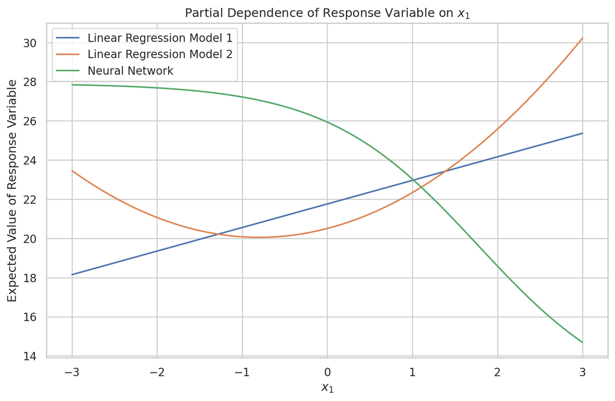

```python
x1_values = np.linspace(val_data['x1'].min(), val_data['x1'].max(), 100)

# Fixing the covariate x2 to the median

median_x2 = val_data['x2'].median()

predictions_1_x1 = regression_1.predict(pd.DataFrame({'x1': x1_values, 'x2': median_x2}))

predictions_2_x1 = regression_2.predict(pd.DataFrame({'x1': x1_values, 'x2': median_x2}))

predictions_nn_x1 = nn.operate(np.column_stack((x1_values, np.full_like(x1_values, median_x2))), best_theta)

df_plot = pd.DataFrame({
    'x1': x1_values,
    'Linear Regression Model 1': np.squeeze(predictions_1_x1),
    'Linear Regression Model 2': np.squeeze(predictions_2_x1),
    'Neural Network': np.squeeze(predictions_nn_x1)
})


df_plot = df_plot.melt(id_vars='x1', var_name='Model', value_name='Predicted Value')

sns.set(style="whitegrid")
plt.figure(figsize=(10, 6))
sns.lineplot(data=df_plot, x='x1', y='Predicted Value', hue='Model')
plt.xlabel('$x_1$')
plt.ylabel('Expected Value of Response Variable')
plt.title('Partial Dependence of Response Variable on $x_1$')
plt.legend(loc='best')
plt.show()
```

We can notice that for $x_1 < 1$ , the neural network predicts higher values than the linear models. For each unit increase where $ -3 < x_1 < 0$ we have a total of 2 unit decay in $\hat{y}$ and a 3 unit decay when it reaches $x_1 = 1$.

Meanwhile, for $x_1 > 1$ we see a fastest decay, so for each unit increase into $x_1$ the predicted value tend to vary in the interval $15 < \hat{y} < 23$.

It is noteworthy that the predicted values range is higher in the neural network compared to the linear models.

## **l)**

Again, for each of the 3 models under study, calculate the percentage of times that the 95% confidence interval (for a new observation!) captured the value of $y_i$. Consider only the data from the test set. In the case of the neural network, assume that approximately $\frac{y_i - \hat{y}}{\hat{\sigma}} \sim N(0, 1)$, where $\hat{\sigma}$ represents the square root of the mean squared error of the network. Comment on the results. Hint: for linear models, use the `predict(mod, interval="prediction")` function.

**Show/hide code**

```python
z = st.norm.ppf(0.975)


models = [
    (regression_1, mse_1, 'Regression 1'),
    (regression_2, mse_2, 'Regression 2'),
    (nn.operate, mse_nn, 'Neural Network')
]

normalized_predictions = {}

# Calculating and printing capture rates for each model

for model, mse, model_name in models:
    if model == nn.operate:
        predictions = (nn.operate(val_data[['x1', 'x2']].to_numpy(), best_theta) - val_data['y'].values.reshape(-1, 1)) / np.sqrt(mse)
    else:
        predictions = (model.predict(val_data[['x1', 'x2']]) - val_data['y']) / np.sqrt(mse)
    capture_rate = calculate_capture_rate(predictions, z)
    print(f"Capture rate for {model_name}: {capture_rate:.2f}%")

    normalized_predictions[model_name] = predictions
```

```
Capture rate for Regression 1: 95.52%
Capture rate for Regression 2: 96.53%
Capture rate for Neural Network: 94.30%
```

These outcomes closely resemble those in j), wherein models with lower Mean Squared Error (MSE) also encompassed a greater portion of the data within the confidence interval. However, this difference is marginal, with the linear model 2 slightly outperforming linear model 1 and the neural network, in that order.

## **m)**

For **linear model 1**, create a scatter plot between $x_1$ and $x_2$, where each point corresponds to an observation from the test set. Identify the points that were contained within their respective confidence intervals using the color green. For the remaining points, use red. Comment on the result.

**Show/hide code**

```python
predictions_model_1 = normalized_predictions['Regression 1']

val_data['capture_status'] = np.where((predictions_model_1 >= -z) & (predictions_model_1 <= z), 'Captured', 'Missed')

color_mapping = {'Captured': 'green', 'Missed': 'red'}


fig = px.scatter(val_data, x='x1', y='x2', color='capture_status', color_discrete_map=color_mapping,
                 title='Captured and Missed Points',
                 labels={'x1': 'X1', 'x2': 'X2', 'capture_status': 'Capture Status'})

fig.update_traces(marker=dict(size=3, opacity=0.6))


fig.update_layout(
    xaxis=dict(title='X<sub>1</sub>'),
    yaxis=dict(title='X<sub>2</sub>'),
    legend=dict(title='Capture Status', orientation='h', yanchor='bottom', y=1.02, xanchor='right', x=1),
    plot_bgcolor='white',
    showlegend=True,
    width=800,
    height=500
)

fig.show()
```

[interactive chart not shown]

The data lying outside the confidence interval predominantly cluster in the area where the function under estimation achieves its peak values. This phenomenon arises due to the incapacity of linear model 1 to capture the nonlinear correlation between $u$, $X_1$, and $X_2$. Despite this limitation, model 1 remains apt for predicting values proximate to the mean.

## **Extra)**

Implement the L2 regularization to find a better MSE for the validation set and comment the results.

**Show/hide code**

```python
best_lambda = None
best_mse = float('inf')
lambda_values = [0.00001,0.0001, 0.001, 0.01, 0.1, 1, 10]

for lambda_val in lambda_values:

    nn.operate(x_train, best_theta, y_train, operation='backpropagation_L2', lambda_val=lambda_val)

    y_val_hat_nn = nn.operate(val_data[['x1', 'x2']].to_numpy(), best_theta, operation='forward_L2', lambda_val=lambda_val )
    y_val =  val_data['y'].to_numpy().reshape(-1, 1)
    mse_val = np.mean((y_val_hat_nn - y_val) ** 2)

    if mse_val < best_mse:
        best_mse = mse_val
        best_lambda = lambda_val

print("Best lambda:", best_lambda)
print(f"Best MSE in the validation set: {best_mse:.2f}")
```

```
Best lambda: 1e-05
Best MSE in the validation set: 140.59
```

Unfortunately the MSE didn’t got a reduction, in fact, it slightly increased suggesting that the regularization might need fine-tuning.